# Getting Started with MARCviz

## Overview

The **MARCviz** package implements the Meta-Analytic Rain Cloud (MARC) plot from Fitzgerald & Tipton (2022), a visualization tool designed to help non-technical users understand meta-analytic results.

It focuses on:

- Emphasizing **precise** studies over imprecise ones
- Emphasizing the **summary effect** over individual studies
- Showing the **magnitude** and **uncertainty** of the summary effect in an intuitive way

This vignette walks you through:

1. Installing **MARCviz**
2. Loading the example data
3. Creating your first MARC plot
4. Using a **metafor** model object

## 1. Installing **MARCviz**

If you haven’t already installed the package, you can install it from GitHub:

```r
# install.packages("devtools")
devtools::install_github("kgfitzgerald/MARCviz")
```

Then load the package:

```r
library(MARCviz)
```

## 2. Loading the example data

**MARCviz** comes with an example meta-analytic dataset called `viz_MA_data`. We’ll use the subset where `k == 50`:

```r
data(viz_MA_data)

ma_dat <- viz_MA_data %>%
  filter(k == 50)

d_j  <- ma_dat %>% pull(d_j)   # effect size estimates
se_j <- ma_dat %>% pull(se_j)  # standard errors

length(d_j)
```

```
#> [1] 50
```

## 3. Creating your first MARC plot

The simplest way to create a MARC plot is to pass vectors of effect sizes (`d_j`) and standard errors (`se_j`) to `viz_MARC()`:

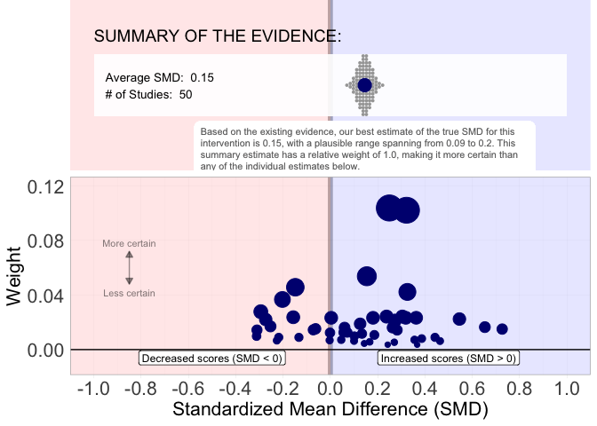

```r
p <- viz_MARC(d_j, se_j)
p
```

### How to read this plot

- Each **dot in the bottom panel** is a study:
  - x-axis: **Standardized Mean Difference (SMD)**
  - y-axis: **Relative weight**. Studies with the largest weights will appear higher and larger on the y-axis.
  - larger and higher dots = more certain, more influential
- The **top panel** shows the meta-analytic **summary effect** as a large dot plus a “cloud” of plausible values for the true effect.
- This cloud is created by generating random values from a normal distribution with mean and standard deviation equal to the mean and standard error of the summary effect.
  - The wider the cloud, the more uncertainty around the summary effect.
  - The cloud is centered on the summary effect estimate.

## 4. Using a **metafor** model object

This example uses the **metafor** package (Viechtbauer, 2010). You can install it from CRAN:

```r
install.packages("metafor")
```

Documentation is available at: https://cran.r-project.org/package=metafor

Now fit a fixed-effects model:

```r
library(metafor)

res_fe <- rma.uni(yi = d_j, sei = se_j, method = "FE")
res_fe
```

```
#>
#> Fixed-Effects Model (k = 50)
#>
#> I^2 (total heterogeneity / total variability):   27.07%
#> H^2 (total variability / sampling variability):  1.37
#>
#> Test for Heterogeneity:
#> Q(df = 49) = 67.1871, p-val = 0.0432
#>
#> Model Results:
#>
#> estimate      se    zval    pval   ci.lb   ci.ub
#>   0.1455  0.0294  4.9538  <.0001  0.0879  0.2030  ***
#>
#> ---
#> Signif. codes:  0 '***' 0.001 '**' 0.01 '*' 0.05 '.' 0.1 ' ' 1
```

Where:

- `yi = d_j` → effect sizes
- `sei = se_j` → standard errors
- `method = "FE"` → fixed-effects model

Now call `viz_MARC()` with the **metafor** object:

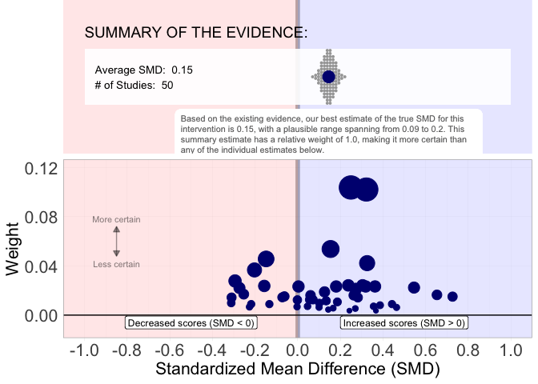

```r
viz_MARC(res_fe)
```

When you pass a **metafor** object, `viz_MARC()`:

- Extracts effect sizes and weights from the model
- Uses the model’s summary estimate and standard error
- Produces the same style of MARC plot

## 5. Next steps

From here, you can:

- Try `show_study_labels = TRUE` to add study labels
- Use your own dataset instead of `viz_MA_data`
- Explore customization options in the help page

```r
?viz_MARC
```

```r
library(MARCviz)
```